# Problema 2 - Checkpoint 2

26 de julho de 2016

# Investigando os gastos dos deputados brasileiros

## Introdução

Esta análise foi realizada com o objetivo de verificar como os deputados brasileiros utilizam a verba destinada ao custeio de suas atividades parlamentares, chamada cota parlamentar. A cota parlamentar foi instituída em 2009 em substituição à verba indenizatória e pode ser utilizada para o pagamento de, entre outras coisas, despesas com meios de locomoção, serviços de comunicação, manutenção de escritórios de apoio, assinatura de publicações, alimentação e hospedagem. Uma descrição mais completa pode ser encontrada no site da câmara dos deputados Os dados utilizados foram obtidos através do Portal da Transparência da câmara dos deputados e dizem respeito ao período entre janeiro e julho de 2016.

### Quais deputados gastam mais em cursos e palestras? E menos?

O principal ponto que estávamos interessados em observar era como os deputados gastam sua cota parlamentar em despesas da categoria de atividades de qualificação, como participação em cursos e palestras. Abaixo podemos observar quais são os deputados que mais gastaram e os que menos gastaram em cursos e palestras até o início de julho de 2016.

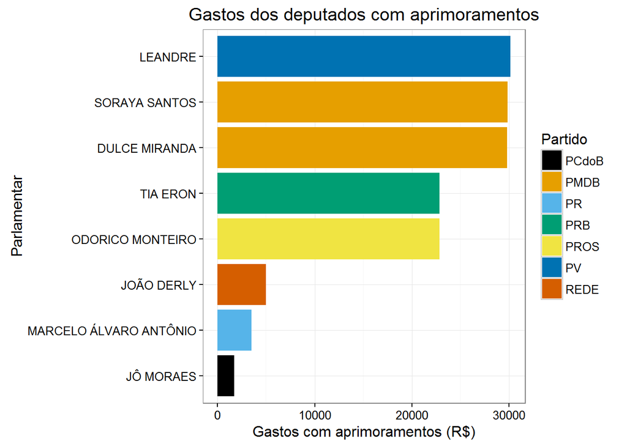

Agora, é possível observar que os deputados que mais gastaram com aprimoramentos foram a deputada Leandre do PV e as deputadas Soraya Santos e Dulce Miranda, ambas do PMDB. 564 deputados não gastaram com aprimoramentos no período, o que corresponde a 98.6% dos parlamentares. Nossos deputados parecem pouco interessados em participar de eventos do tipo. Qual poderia ser a razão por trás disso?